# Feasible omega

# omega_min = 0.9, omega_mod = 1.75, omega_max = 5

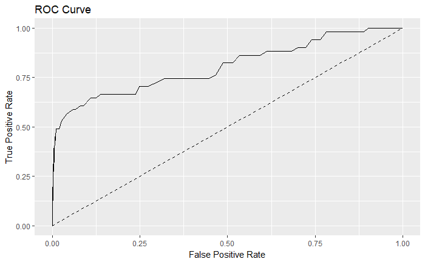

```r
data_11 = read.csv('../../Analysis/Simulations/H3H_phydms_12_50_09_175_5/performancebycutoff.csv')
data_11$omega_min = 0.9
data_11$omega_mod = 1.75
data_11$omega_max = 5
p <- ggplot(data_11, aes(x=1 - data_11$Specificity, y=data_11$Sensitivity)) +
  geom_line() +
  geom_line(data=data_11, aes(x=data_11$Sensitivity, y=data_11$Sensitivity), linetype='dashed') +
  xlab('False Positive Rate') +
  ylab('True Positive Rate') +
  ggtitle('ROC Curve')
p
```

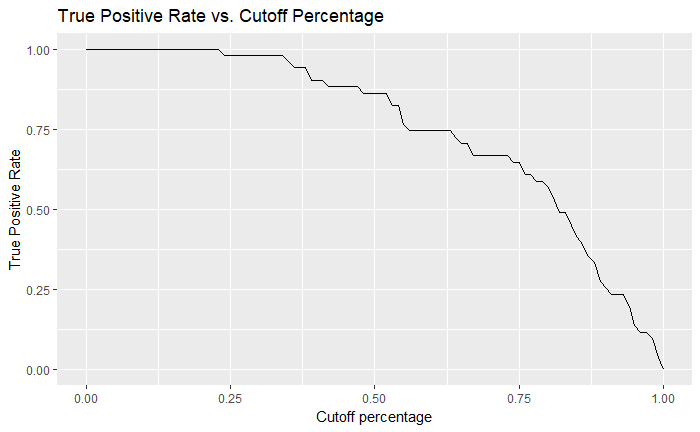

```r
p_2 <- ggplot(data_11, aes(x=data_11$Cutoff.percentage, y=data_11$Sensitivity)) +
  geom_line() +
  xlab('Cutoff percentage') +
  ylab('True Positive Rate') +
  ggtitle('True Positive Rate vs. Cutoff Percentage')
p_2
```

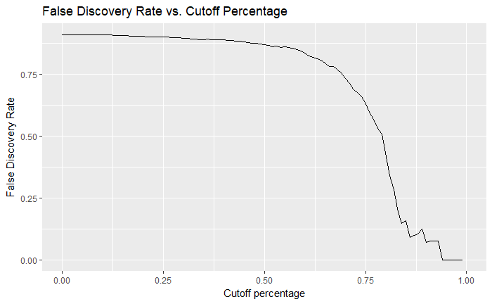

```r
p_3 <- ggplot(data_11, aes(x=data_11$Cutoff.percentage, y=data_11$False.Discovery.Rate)) +
  geom_line() +
  xlab('Cutoff percentage') +
  ylab('False Discovery Rate') +
  ggtitle('False Discovery Rate vs. Cutoff Percentage')
p_3
```

# omega_min = 0.9, omega_mod = 1.75, omega_max = 10

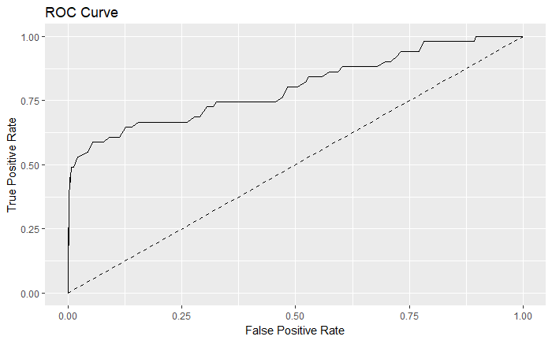

```r
data_12 = read.csv('../../Analysis/Simulations/H3H_phydms_12_50_09_175_10/performancebycutoff.csv')
data_12$omega_min = 0.9
data_12$omega_mod = 1.75
data_12$omega_max = 10
p <- ggplot(data_12, aes(x=1 - data_12$Specificity, y=data_12$Sensitivity)) +
  geom_line() +
  geom_line(data=data_12, aes(x=data_12$Sensitivity, y=data_12$Sensitivity), linetype='dashed') +
  xlab('False Positive Rate') +
  ylab('True Positive Rate') +
  ggtitle('ROC Curve')
p
```

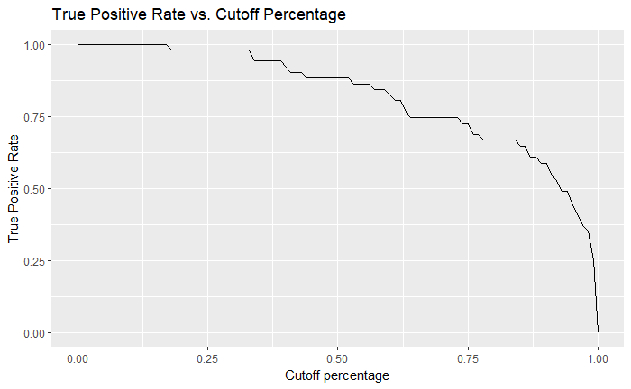

```r
p_2 <- ggplot(data_12, aes(x=data_12$Cutoff.percentage, y=data_12$Sensitivity)) +
  geom_line() +
  xlab('Cutoff percentage') +
  ylab('True Positive Rate') +
  ggtitle('True Positive Rate vs. Cutoff Percentage')
p_2
```

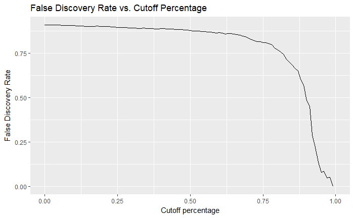

```r
p_3 <- ggplot(data_12, aes(x=data_12$Cutoff.percentage, y=data_12$False.Discovery.Rate)) +
  geom_line() +
  xlab('Cutoff percentage') +
  ylab('False Discovery Rate') +
  ggtitle('False Discovery Rate vs. Cutoff Percentage')
p_3
```

For readability, here is the same information as facet grids.

```r
all_data <- rbind(data_1, data_2, data_3, data_4, data_5, data_6, data_7, data_8, data_9, data_10, data_11, data_12)
write.csv(all_data, '../../Analysis/Simulations/all_data_performancebycutoff.csv', row.names = FALSE)
p_all <- ggplot(all_data, aes(x=all_data$Cutoff.percentage, y=all_data$Sensitivity)) +
  geom_line(shape=1) +
  facet_grid(omega_min ~ omega_mod ~ omega_max) +
  xlab('Cutoff Percentage') +
  ylab('True Positive Rate') +
  ggtitle('True Positive Rate vs. Cutoff Percentage')
```

```
Ignoring unknown parameters: shape
```

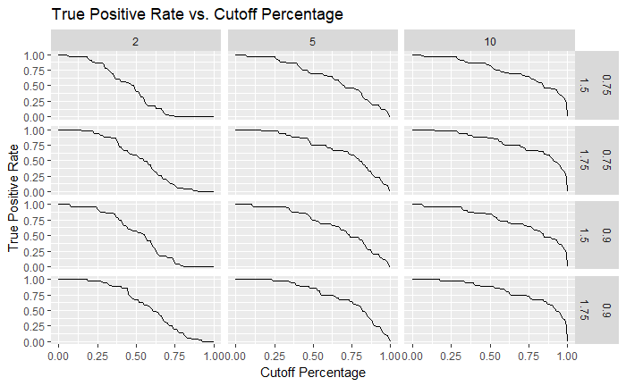

```r
p_all
```

```r
p_all <- ggplot(all_data, aes(x=all_data$Cutoff.percentage, y=all_data$False.Discovery.Rate)) +
  geom_line(shape=1) +
  facet_grid(omega_min ~ omega_mod ~ omega_max) +
  xlab('Cutoff Percentage') +
  ylab('False Discovery Rate') +
  ggtitle('False Discovery Rate vs. Cutoff Percentage')
```

```
Ignoring unknown parameters: shape
```

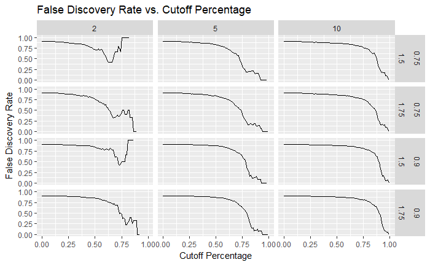

```r
p_all
```

```r
p_all <- ggplot(all_data, aes(x=1 - all_data$Specificity, y=all_data$Sensitivity)) +
  geom_line(shape=1) +
  geom_line(data=all_data, aes(x=all_data$Specificity, y=all_data$Specificity), linetype='dashed') +
  facet_grid(omega_min ~ omega_mod ~ omega_max) +
  xlab('False Positive Rate') +
  ylab('True Positive Rate') +
  ggtitle('ROC Curve')
```

```
Ignoring unknown parameters: shape
```

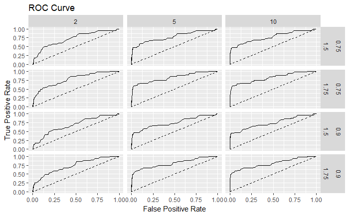

```r
p_all
```

For clarification, the columns of the facet grid correspond to values of `omega_max`, the rows indicated by the outer labels correspond to values of `omega_min`, and the rows indicated by the inner labels correspond to values of `omega_mod`.

For the facet grid describing the rate of true positives, we would expect that as the cutoff percentage approaches one, the true positive rate should approach zero. Ideally, we have a high true positive rate for as high of a cutoff percentage as possible.

Recall that the formula for false discovery rate is given by (False positives) / (True positives + False positives), i.e., the number of false positives divided by the total number of positive signals. For the facet grid describing the false discovery rate, we observe that the false discovery rate either cuts off (because there are no positive signals), or reaches zero (because there are no false positives).

Of note, all of the ROC curves are above the y=x line, which is desirable as it suggests that for all cutoff percentages, the True positive rate is greater than the false positive rate. Ideally, we would observe a large large vertical spike near the beginning of the ROC curve, as that would indicate that there are datapoints where there is essentially no false positives.